# RFdiffusion Background

# RFdiffusion

## Background

We will start by using the RFdiffusion binder design protocol, as described in the following papers:

- Watson, J.L., Juergens, D., Bennett, N.R. et al. “De novo design of protein structure and function with RFdiffusion.”, *Nature*, **620**, 1089–1100 (2023). https://doi.org/10.1038/s41586-023-06415-8 - Github: https://github.com/RosettaCommons/RFdiffusion
- Bennett, N.R., Coventry, B., Goreshnik, I. et al. Improving de novo protein binder design with deep learning. *Nat Commun*, **14**, 2625 (2023). https://doi.org/10.1038/s41467-023-38328-5 - Github: https://github.com/nrbennet/dl_binder_design
- Dauparas, J. et al. Robust deep learning–based protein sequence design using ProteinMPNN. *Science*, **378**,49-56(2022). https://doi.org/10.1126/science.add2187 - Github: https://github.com/dauparas/ProteinMPNN

This method combines:

- RFdiffusion for generating the backbone of a designed binder for a target structure

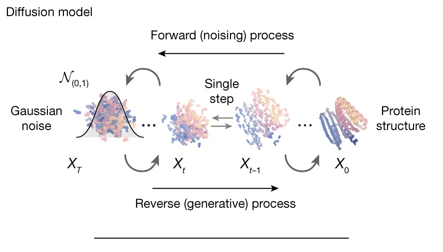

Diffusion, from Fig 1 of Watson *et al* 2023 https://doi.org/10.1038/s41586-023-06415-8, CC-BY 4.0

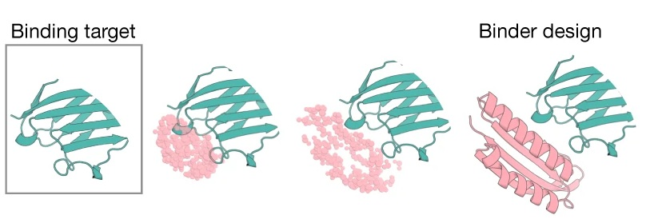

Generative binder design via denoising, Fig 1 of Watson *et al* 2023 https://doi.org/10.1038/s41586-023-06415-8, CC-BY 4.0

- ProteinMPNN-FastRelax for ‘inverse folding’ to generate a sequence for the binder backbone
- Alphafold2 ‘initial guess’ structure prediction to quickly score binders *in silico*
  - To make predictions faster, Alphafold2 ‘initial guess’ doesn’t use the multiple sequence alignment (MSA) input and provides the initial target+binder complex coordinates as a starting point in the first recycle.

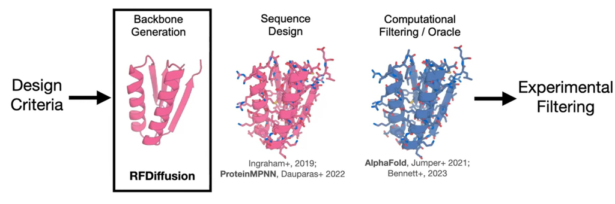

From this presentation https://www.youtube.com/watch?v=828WPIIOwaA by Brian Trippe, Columbia University

- ‘Full’ Alphafold2 on best binders to check conformational stability of binder monomers, verify complexes

**CautionSoftware licensing**

[output not shown]